# Klasteryzacja k - średnich

## Zestaw danych

W projekcie zajmujemy się zestawem danych Wine, który zawiera 8 zmiennych i 100 obserwacji dotyczących różnych win. Będziemy korzystać z 6 zmiennych, które są typu liczbowego.

- **Rating** - ocena smaku wina w skali od 1 do 100
- **Price** - cena wyrażona w dolarach
- **Alcohol** - procentowa zawartość alkoholu
- **Residual Sugar** - ilość pozostałego cukru po procesie fermentacji
- **Sulphates** - związki siarki dodawane do wina
- **pH** - wskaźnik pH

## Analiza skupień - klasteryzacja

Jest techniką analizy danych używaną w dziedzinie uczenia maszynowego i statystyki. Jej celem jest podział zbioru danych na grupy (klasycznie nazywane klastrami) składające się z podobnych do siebie obiektów. Podstawowe założenie klasteryzacji polega na tym, że obiekty w obrębie jednego klastra są bardziej do siebie podobne niż do obiektów z innych klastrów.

## Metoda k - średnich

Jest to jedna z metod klasteryzacji danych.  
Grupowanie polega na wstępnym podzieleniu populacji na z góry założoną liczbę klas.  
Podstawowy algorytm metody:

- wybór środków klas (centroidów)
- przypisanie punktów do najbliższych centroidów
- wyliczenie nowych środków skupień
- powtarzanie algorytmu aż do osiągnięcia kryterium zbieżności

## Działanie aplikacji

## Zastosowanie klasteryzacji

Algorytm k-średnich jest stosowany do danych za pomocą funkcji `kmeans`.  
Liczba klastrów jest określana przez wartość wybraną przez użytkownika za pomocą suwaka (`input$clusters`)  
Parametry `iter.max` i `nstart` kontrolują maksymalną liczbę iteracji i liczbę różnych punktów początkowych dla algorytmu

```r
  clusters <- reactive
  (
    {
    kmeans(data(), centers = input$clusters,
           iter.max = 100, nstart = 100)
    }
  )
```

## Wykresy

## Elbow Method

Jest graficzną metodą znajdywania najbardziej optymalnej wartości k (liczby klastrów). Wykorzystuje WSS (Within-Cluster Sum of Squares) - mierzy jak bardzo rozproszone są punkty w obrębie klastra wykorzystując sumę odległości kwadratów między każdym punktem danych a przypisanym mu środkiem klastra.

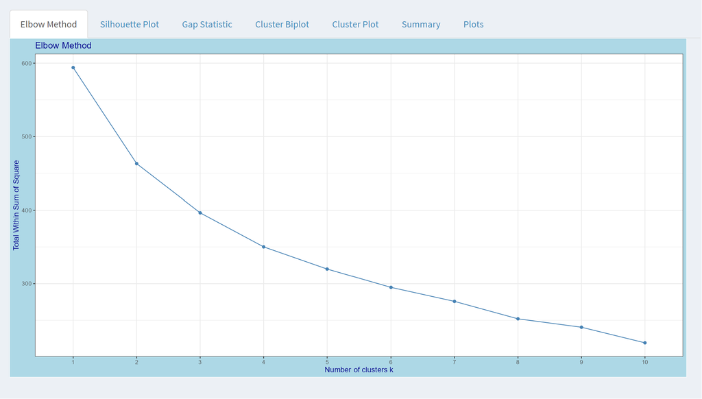

```r
output$nbClustersPlot <- renderPlot
(
  {
    fviz_nbclust(data(), kmeans, method = "wss") +
      ggtitle("Elbow Method") +
      myTheme()
  }
)
```

W miarę zwiększania liczby klastrów WSS maleje. Najbardziej optymalna liczba klastrów to ta, gdzie tempo spadku WSS znacząco zwalnia.

## Silhouette Plot

Wykres przedstawia miarę silhouette dla różnych liczby klastrów. Miara silhouette ocenia, jak dobrze każdy obiekt pasuje do swojego klastra w porównaniu do innych klastrów. Wartości bliskie 1 wskazują na dobrą klastryzację, podczas gdy wartości bliskie -1 oznaczają, że obiekty są źle przypisane do klastrów.

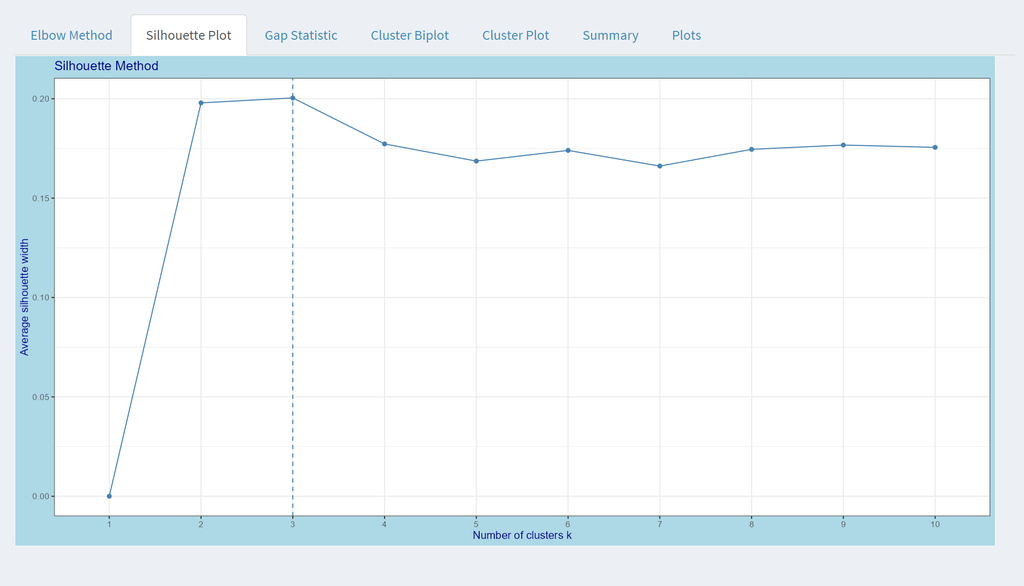

```r
output$silhouettePlot <- renderPlot
(
  {
    fviz_nbclust(data(), kmeans, method = "silhouette") +
      ggtitle("Silhouette Method") +
      myTheme()
  }
)
```

Wybieramy liczbę klastrów, dla której wartość silhouette jest maksymalna - czyli obiekty mają najlepsze dopasowanie do swojego klastra

## Gap Statistic

Wykres przedstawia statystykę gap, która porównuje WSS rzeczywistych danych do WSS uzyskanego dla danych losowych. Optymalna liczba klastrów to ta, dla której wartość gap jest największa, co oznacza, że klastry w danych są bardziej skoncentrowane niż w danych losowych.

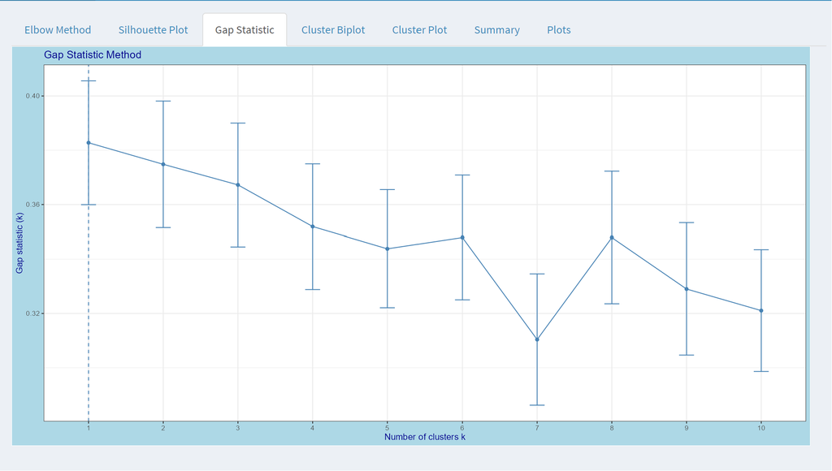

```r
output$gapStatPlot <- renderPlot
(
  {
    fviz_nbclust(data(), kmeans, method = "gap_stat") +
      ggtitle("Gap Statistic Method") +
      myTheme()
  }
)
```

Największa wartość gap jest dla k równego 1.

## Cluster Biplot

Biplot przedstawia strukturę klastrów na płaszczyźnie. Każdy obiekt jest reprezentowany jako punkt, a centra klastrów jako punkty centralne. W zależności od wyboru liczby klastrów przez użytkownika (1-10) wykres ma różny wygląd.

```r
output$clusterBiplot <- renderPlot({
    fviz_cluster(clusters(), data = data()) +
      myTheme()
  })
```

## Cluster Biplot dla k = 3

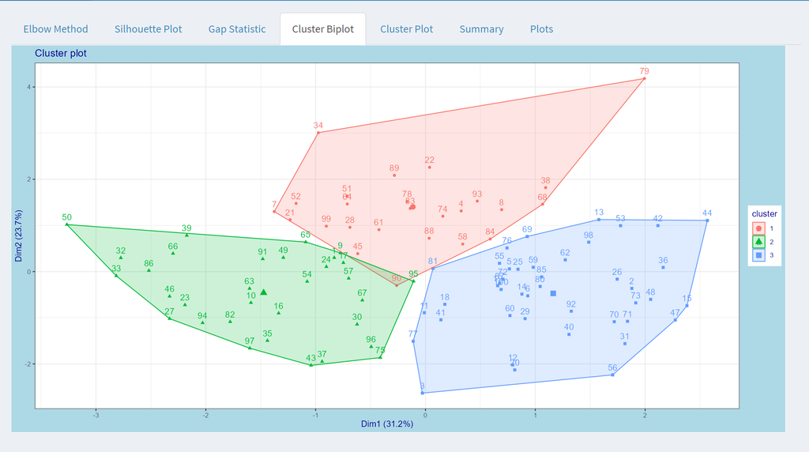

## Cluster Biplot dla k = 7

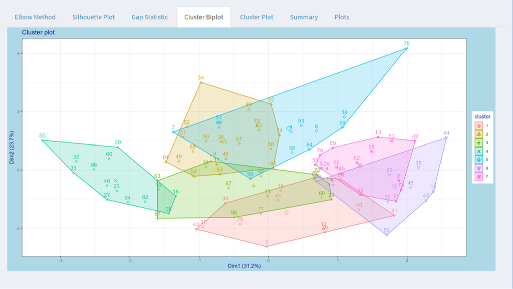

## Cluster Plot

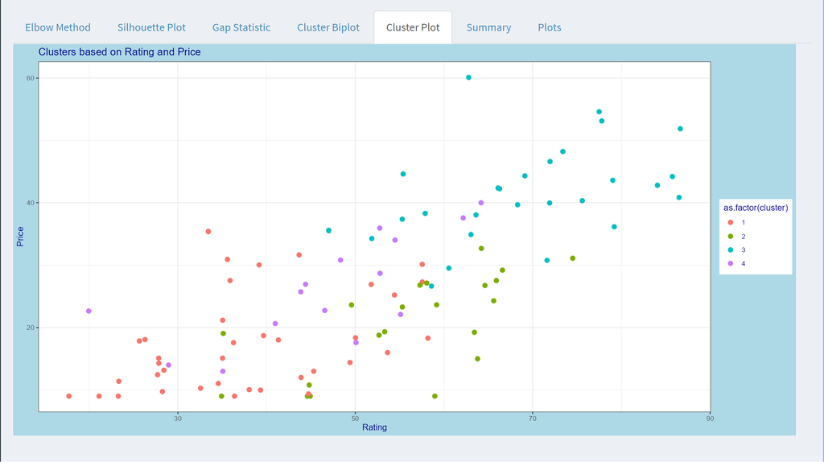

Na wykresie punktowym przedstawione są klastry, z których każdy jest oznaczony innym kolorem. Wykres dla k = 4

## Summary

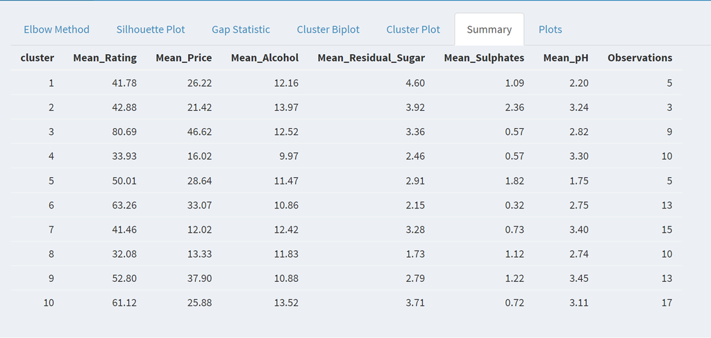

Dla wybranej liczby klastrów - obliczenie średnich wszystkich zmiennych.

## Plots

Ostatnia zakładka projektu pozwala na interaktywne tworzenie wykresów. Użytkownik może wybrać jeden z trzech dostępnych typów wykresu (histogram, krzywą gęstości lub wykres pudełkowy) oraz zmienną, której ma dotyczyć wykres. Dodatkowo dla histogramu może wybrać liczbę klas.

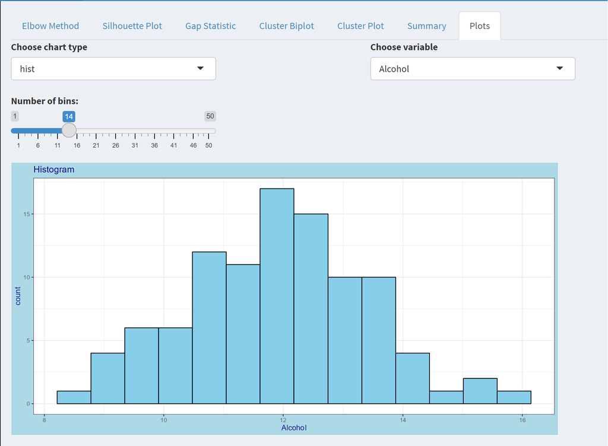

Histogram - zawartość alkoholu (dla 14 klas)

## Źródła

- https://pl.wikipedia.org/wiki/Analiza_skupie%C5%84”
- https://pl.wikipedia.org/wiki/Analiza_skupie%C5%84
- https://jakbadacdane.pl/analiza-skupien-na-przykladzie-algorytmu-k-srednich
- https://www.rdocumentation.org/packages/stats/versions/3.6.2/topics/kmeans
- https://www.analyticsvidhya.com/blog/2019/08/comprehensive-guide-k-means-clustering/
- https://towardsdatascience.com/understanding-k-means-clustering-in-machine-learning-6a6e67336aa1

Zestaw danych pochodzi ze strony https://www.kaggle.com/